# Unidad 2: R Studio y El Tidyverse

# *Overview*

El propósito de esta unidad es aplicar los conocimientos del curso [*Introduction to the Tidyverse*](https://www.datacamp.com/courses/introduction-to-the-tidyverse) a dos bases de datos lexicográficos: [*A Frequency Dictionary of Spanish: Core Vocabulary for Learners (Routledge Frequency Dictionaries)*](https://www.amazon.com/Frequency-Dictionary-Spanish-Vocabulary-Dictionaries/dp/0415334292) (una sub muestra), [*English Grammar Profile*](https://www.englishprofile.org/english-grammar-profile?); y unos datos sociofonéticos de mi tesis de maestría. Puedes utilizar `git clone` para descargar todas las materiales:

```bash
# Por hacer: crear un repositorio por separado con todas las materiales de esta unidad o configurar la descarga de un subdirectorio
git clone https://github.com/axme100/rclass
```

# ¿Cómo cargar datos en R?

## Con *Absolute Path*

```r
spanLexData <- read.csv("/Users/maxcarey/Documents/proj/rclass/docs/unidadDos/spanLexData.csv")
```

Acuérdate que siempre es mejor utilizar *relative paths* porque hace que tu *script* sea más transferible a otras personas. Es decir, el *path* de arriba, no funcionaría en tu maquina, pues tendrías que poner tu proio nombre. Si nuestro *script* y nuestros datos están en la misma carpeta solo tenemos que decirle a R que identifica esta carpeta como el directorio activo. En R Studio, con el *script* meta que estémos utilizando se hace: `Session` -> `Set Working Directory` -> `To Source File Location` (Ve abajo):

[figure not shown]

working_directory

## Con *Relative Path*

```r
spanLexData <- read.csv("spanLexData.csv")
```

## En *R Studio*

- Ayuda muchísimo `import dataset`

# ¿Cómo son estos datos?

## Con `str()`

```r
str(spanLexData)
```

```
## 'data.frame':    2500 obs. of  10 variables:
##  $ rank      : int  48 2406 1362 1207 2616 2183 2307 2336 1800 1746 ...
##  $ headword  : Factor w/ 2446 levels "a","abajo","abandonado",..: 2187 1638 325 723 1872 2016 2083 1676 109 654 ...
##  $ pos       : Factor w/ 17 levels "adj","adv","aj",..: 15 9 9 17 11 2 1 9 9 9 ...
##  $ english   : Factor w/ 2465 levels "(alive) fish",..: 1159 2387 216 1889 1312 411 1441 1216 80 423 ...
##  $ sample    : Factor w/ 2499 levels "-Vi que mi posición en aquel momento era inútil",..: 413 646 1031 529 551 387 628 1596 147 1374 ...
##  $ range     : int  100 85 93 100 81 80 79 83 91 91 ...
##  $ rawFreq   : int  35038 539 2230 1174 550 999 1346 611 823 1334 ...
##  $ oral      : Factor w/ 2 levels "high","low": NA NA NA NA NA 1 NA NA NA NA ...
##  $ fiction   : Factor w/ 1 level "low": NA NA NA NA NA NA NA NA NA NA ...
##  $ nonFiction: Factor w/ 1 level "low": NA NA NA NA NA 1 NA NA NA NA ...
```

## Con `glimpse()`

```r
# library(dplyr)
glimpse(spanLexData)
```

```
## Observations: 2,500
## Variables: 10
## $ rank       <int> 48, 2406, 1362, 1207, 2616, 2183, 2307, 2336, 1800,...
## $ headword   <fct> sobre, ola, campaña, destruir, príncipe, repente, r...
## $ pos        <fct> prep, nf, nf, v, nm, adv, adj, nf, nf, nf, nm, num,...
## $ english    <fct> on top of, over, about, wave, billow, campaign, to ...
## $ sample     <fct> dejó el papel sobre la mesa y se fue, el sonido era...
## $ range      <int> 100, 85, 93, 100, 81, 80, 79, 83, 91, 91, 82, 89, 8...
## $ rawFreq    <int> 35038, 539, 2230, 1174, 550, 999, 1346, 611, 823, 1...
## $ oral       <fct> NA, NA, NA, NA, NA, high, NA, NA, NA, NA, NA, high,...
## $ fiction    <fct> NA, NA, NA, NA, NA, NA, NA, NA, NA, NA, NA, NA, NA,...
## $ nonFiction <fct> NA, NA, NA, NA, NA, low, NA, NA, NA, NA, NA, NA, NA...
```

## Con `View()`

```r
View(spanLexData)
```

## Con `head()`

```r
head(spanLexData)
```

```
##   rank headword  pos                english
## 1   48    sobre prep on top of, over, about
## 2 2406      ola   nf           wave, billow
## 3 1362  campaña   nf               campaign
## 4 1207 destruir    v       to destroy, ruin
## 5 2616 príncipe   nm                 prince
## 6 2183  repente  adv de + repente: suddenly
##                                                         sample range
## 1                         dejó el papel sobre la mesa y se fue   100
## 2                  el sonido era un poco como las olas del mar    85
## 3 fueron expresadas en una nueva campaña de reforma ideológica    93
## 4             el equipo militar piensa destruir a este enemigo   100
## 5      el heredero es su hijo mayor, Carlos, príncipe de Gales    81
## 6                               de repente nos tiramos al agua    80
##   rawFreq oral fiction nonFiction
## 1   35038 <NA>    <NA>       <NA>
## 2     539 <NA>    <NA>       <NA>
## 3    2230 <NA>    <NA>       <NA>
## 4    1174 <NA>    <NA>       <NA>
## 5     550 <NA>    <NA>       <NA>
## 6     999 high    <NA>        low
```

## Con `unique()`

```r
unique(spanLexData$pos)
```

```
##  [1] prep    nf      v       nm      adv     adj     num     nm/f
##  [9] pron    nc      nmf     conj    nf (el) aj      interj  n
## [17] art
## 17 Levels: adj adv aj art conj interj n nc nf nf (el) nm nm/f nmf ... v
```

# ¿Cómo podemos ordenar esta base de datos?

```r
spanLexData <- spanLexData %>%
  arrange(rank)
```

# ¿Qué tan frecuente es la palabra más frecuente?

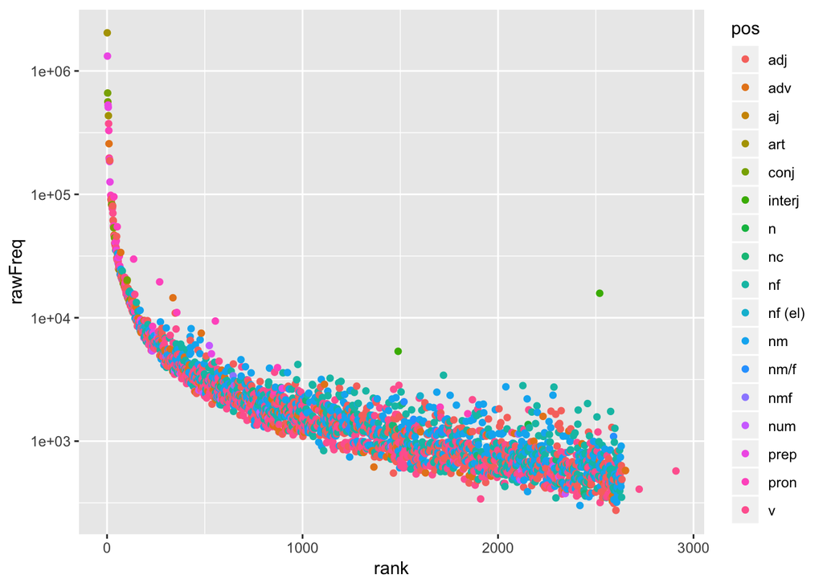

```r
ggplot(spanLexData, aes(y = rawFreq, x = rank, color = pos)) + geom_point() + scale_y_log10()
```

# Se observa el mismo patrón por cada POS?

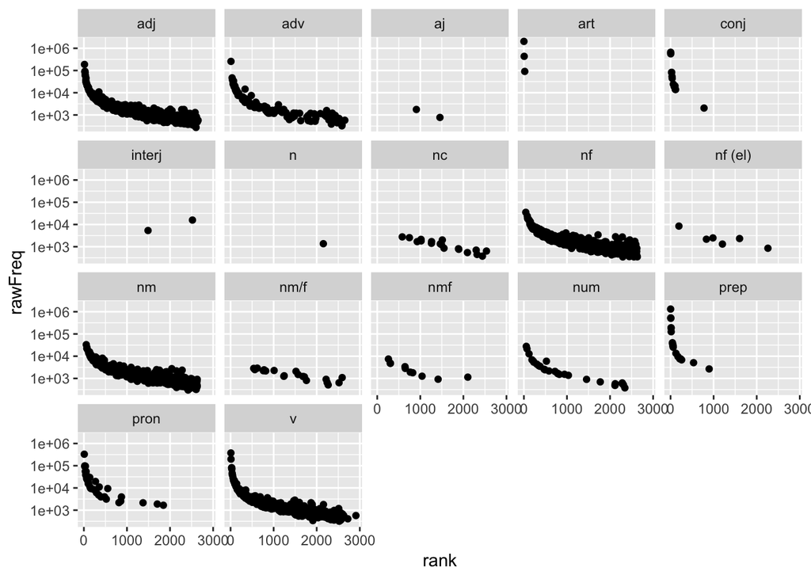

```r
ggplot(spanLexData, aes(y = rawFreq, x = rank)) + geom_point() + scale_y_log10() + facet_wrap(~pos)
```